# Introduction to R

2017년 9월 6일

## What is R?

R is an open source programming language and software environment for statistical computing and graphics that is supported by the R Foundation for Statistical Computing. The R language is widely used among statisticians and data miners for developing statistical software and data analysis. Polls, surveys of data miners, and studies of scholarly literature databases show that R's popularity has increased substantially in recent years. - Wikipedia

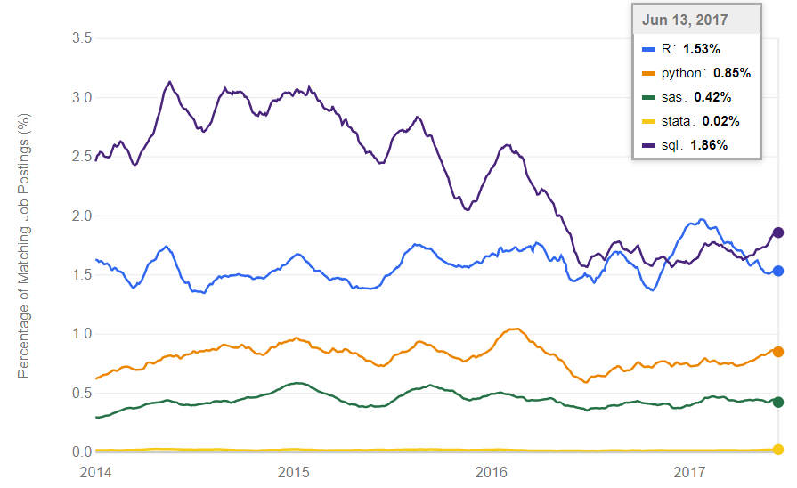

Source: Indeed

## What is the advantage of using R?

Comparing R and Python, they have their own advantages and disadvantages against each other because of their purposes. Python is the languages that is developed for simplifying the process of programming in general. On the other hand, R is developed for statistical analysis. Because of their distinct uses, we can identify when to use R and Python at different situations.

R has lots of advantages conducting and practicing statistical analysis comparing to Python because most basic functions of R are created for statistical analysis - both descriptive and inferential statistics. Also, R provides lots of datasets at different situation for practice. For example,

```r
data("iris")
head(iris)
```

```
##   Sepal.Length Sepal.Width Petal.Length Petal.Width Species
## 1          5.1         3.5          1.4         0.2  setosa
## 2          4.9         3.0          1.4         0.2  setosa
## 3          4.7         3.2          1.3         0.2  setosa
## 4          4.6         3.1          1.5         0.2  setosa
## 5          5.0         3.6          1.4         0.2  setosa
## 6          5.4         3.9          1.7         0.4  setosa
```

## Hello World

```
## [1] "Hello World"
```

Python and R share similar grammar since they aim at simplicity.

## Nice Visualization

The strength of open source language is that the growth is exponential. Since R is strong statistical programming language, it is also a very good tool for data visualization

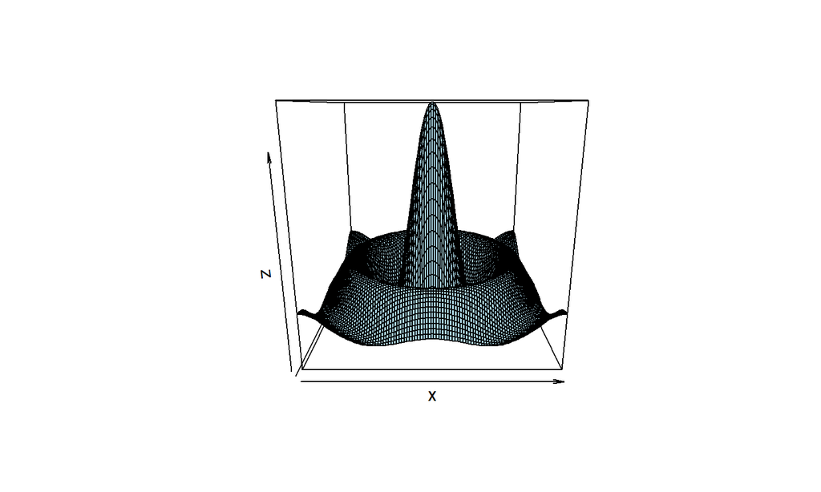

## What is the best timing for using R?

In my opinion, R is more useful than Python when we conduct inferential statistics and linear algebra. Also, if your are interested in creating your own function that conducts statistical analysis, R would be a good working environment to do it.

One and foremost advatange of R against Python is this: vectorization.

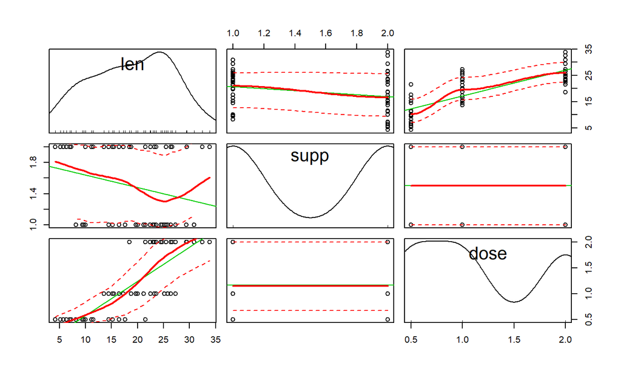

## Vectorization: Why is it a big deal?

Since I am not a computer sicentist or computer engineer, I cannot explain thing technically or theoratically, but the advantage of vectorization is that when you use and assign data, you can manage the memory of your computer better. In other words, you can write a simple code to construct functions or dataset in R. For further information, [http://www.noamross.net/blog/2014/4/16/vectorization-in-r–why.html](http://www.noamross.net/blog/2014/4/16/vectorization-in-r--why.html) explains the strength of vectorization well.

For example, from iris data presented previously,

```r
sepal_length_vector <- iris$Sepal.Length
sepal_length_vector
```

```
##   [1] 5.1 4.9 4.7 4.6 5.0 5.4 4.6 5.0 4.4 4.9 5.4 4.8 4.8 4.3 5.8 5.7 5.4
##  [18] 5.1 5.7 5.1 5.4 5.1 4.6 5.1 4.8 5.0 5.0 5.2 5.2 4.7 4.8 5.4 5.2 5.5
##  [35] 4.9 5.0 5.5 4.9 4.4 5.1 5.0 4.5 4.4 5.0 5.1 4.8 5.1 4.6 5.3 5.0 7.0
##  [52] 6.4 6.9 5.5 6.5 5.7 6.3 4.9 6.6 5.2 5.0 5.9 6.0 6.1 5.6 6.7 5.6 5.8
##  [69] 6.2 5.6 5.9 6.1 6.3 6.1 6.4 6.6 6.8 6.7 6.0 5.7 5.5 5.5 5.8 6.0 5.4
##  [86] 6.0 6.7 6.3 5.6 5.5 5.5 6.1 5.8 5.0 5.6 5.7 5.7 6.2 5.1 5.7 6.3 5.8
## [103] 7.1 6.3 6.5 7.6 4.9 7.3 6.7 7.2 6.5 6.4 6.8 5.7 5.8 6.4 6.5 7.7 7.7
## [120] 6.0 6.9 5.6 7.7 6.3 6.7 7.2 6.2 6.1 6.4 7.2 7.4 7.9 6.4 6.3 6.1 7.7
## [137] 6.3 6.4 6.0 6.9 6.7 6.9 5.8 6.8 6.7 6.7 6.3 6.5 6.2 5.9
```

## Continued

Also, you can change it into the matrix with one column

```r
sepal_length_matrix <- matrix(sepal_length_vector,ncol=1)
head(sepal_length_matrix)
```

```
##      [,1]
## [1,]  5.1
## [2,]  4.9
## [3,]  4.7
## [4,]  4.6
## [5,]  5.0
## [6,]  5.4
```

This is the beauty of R. In Python, if you want to vectorize your data and transform it into matrix, you need a package called "numpy," while R already has it in default.

## Cont'd

Also, you can turn that matrix into the dataframe:

```r
sepal_length_dataframe <- as.data.frame(sepal_length_matrix)
names(sepal_length_dataframe) <- "Sepal.Length"
head(sepal_length_dataframe)
```

```
##   Sepal.Length
## 1          5.1
## 2          4.9
## 3          4.7
## 4          4.6
## 5          5.0
## 6          5.4
```

## Does it mean R is better than Python?

No. I am just saying R is relatively better in conducting statistical analysis in nature. Python is the programming language for various purposes such as automization. If you want to develop AI (I don't think whether most of us are interested in that…), your own customized program, or else, Python will be your best choice.

It is your choice to choose which one to use at when.

The potential for R is this: while Python has multiple platforms like Pycharm, Spyder, Jupyter Notebook, and so on, R has RStudio alone (there could be others, but they are usually bad and people don't use them). Which means, since most users consume and enjoy this platform a lot, RStudio developed lots of convenient services for R users - they may not have a competitor in the market of R, but their major competitors are Python, SPSS, STATA, SAS, etc. Many geniuses in the world develop and provide various services for R users. This presentation is one of the abilities of RStudio.

## For the last:

There will be a "R User Conference in Korea 2017" in October 28 (Saturday) in Seoul. **R User Conference in Korea 2017** is one of the biggest R conference in Korea.

Contributed talkers from various institutions: Naver, Korea Statistics, NVIDIA, Seoul National University, KakaoPay, etc.

Topics:

- R Shiny
- Deep Learning
- Changes in the paradigm of research for applicable research
- Open Data Analysis
- Text Analysis
- Web technology

You can register through below link after September 30:

http://ruck2017.r-kor.org/#pagecontent

If you are interested, please go to the above link and register in September 30.